# Apprentissage Statistique - Compte rendu du TP1

*Par Alexandre COMBESSIE et Saad MACHRAOUI*

# Réponses aux questions de la partie 4.6

## 1. Régression linéaire multiple:

### a. Calcul des coefficients de la régression:

La fonction lm prend en compte les variables catégorielles en les transformant en variables indicatrices de chaque modalité. Pour que le modèle reste identifiable, la fonction enlève automatiquement une des modalités (sinon la somme des indicatrices ferait 1, ce qui rendrait la matrice de régression non inversible). Ici la fonction a enlevé la modalité “seasonautumn”, la modalité “sizehigh” et la modalité “speedhigh”.

La quantité qui sert à mesurer la qualité d’ajustement par un modèle linéaire est le R2, qui varie entre 0 (modèle non ajusté) et 1 (modèle parfaitement ajusté). Ici le R2 vaut 0.3716291 ce qui est faible. Le modèle est donc mal ajusté.

### b. Pour choisir les variables pertinentes:

On voit que les variables avec un pvalue supérieures à 5% ne sont clairement pas utiles pour prévoir la variable a1. Il s’agit des variables “season”, “NH4” et “Chla”. Remarque: elles sont identifiables dans la sortie R car elles n’ont pas d’étoiles.

### c. Pour déterminer un sous-modèle qui ne contient pas de variable inutile:

Les variables retenues sont “size”, “mxPH”, “mnO2”, “NO3”, NH4“, et”PO4“. On remarque que ce n’est pas exactement ce qu’on aurait obtenu en enlevant les variables non utiles identifiés par l’ANOVA. On remarque que le nouveau R2 est 0.3559499 à comparer à 0.3716291. La qualité d’ajustement a donc légèrement baissé. C’est logique car on le R2 augmente mécaniquement avec le nombre de variables explicatives.

### e. Pour calculer les prévisions sur les 140 observations de test qui se trouvent dans le tableau fourni avec algae:

```r
test.algae_imputed = knnImputation(test.algae, k =10, meth = "median")
nrow(test.algae[!complete.cases(test.algae),])
```

```
## [1] 18
```

```r
lm.predictions.a1 = predict(final.lm, test.algae_imputed)
rt.predictions.a1 = predict(rt.a1, test.algae_imputed)
```

On regarde la performance sur l’échantillon de test en prenant les solutions:

```r
# La qualité des prédictions fournies par la régression linéaire multiple:
regr.eval(algae.sols[, "a1"], lm.predictions.a1, train.y = algae.sols[, "a1"])
```

```
##         mae         mse        rmse        mape        nmse        nmae
##  12.5212867 276.4443244  16.6266149         Inf   0.6586282   0.7901646
```

```r
# La qualité des prédictions fournies par l'arbre de décision:
regr.eval(algae.sols[, "a1"], rt.predictions.a1, train.y = algae.sols[, "a1"])
```

```
##         mae         mse        rmse        mape        nmse        nmae
##  11.6521000 285.7375654  16.9037737         Inf   0.6807694   0.7353140
```

### f. Evaluer la qualité des prédictions fournies pour les 7 algae:

```r
rt.regeval <- matrix(nrow = 7, ncol = 6, dimnames = list((c(paste("a", 1:7))),
    c("mae", "mse", "rmse", "mape", "nmse", "nmae")))

lm.regeval <- matrix(nrow = 7, ncol = 6, dimnames = list((c(paste("a", 1:7))),
    c("mae", "mse", "rmse", "mape", "nmse", "nmae")))
algae_training <- algae
algae_test <- cbind(test.algae_imputed, algae.sols)

for (a in 1:7) {

    form <- as.formula(paste(names(algae_training)[11 + a], "~."))
    l.model <- lm(form, algae_training[, c(1:11, 11 + a)])
    l.model <- step(l.model)
    l.model.preds <- predict(l.model, algae_test[, c(1:11, 11 + a)])

    r.model <- rpart(form, algae_training[, c(1:11, 11 + a)])
    r.model.preds <- predict(r.model, algae_test[, c(1:11, 11 + a)])

    # PLOTS MIS EN COMMENTAIRE par(lwd=2, col='red') plot(r.model,
    # compress=TRUE) text(r.model, use.n=TRUE,col='blue')

    # PLOTS MIS EN COMMENTAIRE par(mfrow = c(1, 2), col='navy',
    # bg='lemonchiffon1') plot(l.model.preds, algae_f[, c(11+a)], main = 'Linear
    # Model', xlab = 'Predictions', ylab = 'True Values', xlim=c(-15,62))
    # abline(0, 1, lty = 2); plot(r.model.preds, algae_f[, c(11+a)], main =
    # 'Regression Tree', xlab = 'Predictions', ylab = 'True Values',
    # xlim=c(-15,62)) abline(0, 1, lty = 2);

    lm.regeval[a, ] <- regr.eval(algae_test[, c(11 + a)], l.model.preds, train.y = algae_test[,
        c(11 + a)])
    rt.regeval[a, ] <- regr.eval(algae_test[, c(11 + a)], r.model.preds, train.y = algae_test[,
        c(11 + a)])

}
```

```r
#Qualité des prédictions pour la régression
knitr::kable(lm.regeval)
```

|  | mae | mse | rmse | mape | nmse | nmae |
| --- | --- | --- | --- | --- | --- | --- |
| a 1 | 12.521287 | 276.444324 | 16.626615 | Inf | 0.6586282 | 0.7901646 |
| a 2 | 6.857122 | 102.668723 | 10.132558 | Inf | 0.9597227 | 0.9263622 |
| a 3 | 3.857851 | 28.274763 | 5.317402 | Inf | 0.9234110 | 0.9660201 |
| a 4 | 1.880347 | 7.680753 | 2.771417 | Inf | 1.0034860 | 1.0402261 |
| a 5 | 5.435439 | 80.620120 | 8.978871 | Inf | 0.8845942 | 0.8331452 |
| a 6 | 7.219987 | 145.601005 | 12.066524 | Inf | 0.8169790 | 0.8021262 |
| a 7 | 2.902611 | 24.004400 | 4.899428 | Inf | 1.1349965 | 1.2680071 |

```r
#Qualité des prédictions pour l'arbre de décision
knitr::kable(rt.regeval)
```

|  | mae | mse | rmse | mape | nmse | nmae |
| --- | --- | --- | --- | --- | --- | --- |
| a 1 | 11.652100 | 285.73757 | 16.903774 | Inf | 0.6807694 | 0.7353140 |
| a 2 | 7.085475 | 117.71136 | 10.849487 | Inf | 1.1003376 | 0.9572115 |
| a 3 | 4.390141 | 40.64478 | 6.375326 | Inf | 1.3273971 | 1.0993076 |
| a 4 | 1.796962 | 8.43431 | 2.904188 | Inf | 1.1019378 | 0.9940968 |
| a 5 | 5.233454 | 90.21315 | 9.498060 | Inf | 0.9898525 | 0.8021848 |
| a 6 | 6.820982 | 140.31086 | 11.845289 | Inf | 0.7872956 | 0.7577976 |
| a 7 | 2.481910 | 22.62053 | 4.756105 | Inf | 1.0695633 | 1.0842237 |

# Annexes :

## 1. Régression linéaire multiple:

### a. Calcul des coefficients de la régression:

```r
library(car)
library(lattice)
library(DMwR)
algae = knnImputation(algae, k =10, meth = "median")
lm.a1 <- lm(a1 ~ ., data = algae[, 1:12])
summary(lm.a1)
```

```
##
## Call:
## lm(formula = a1 ~ ., data = algae[, 1:12])
##
## Residuals:
##     Min      1Q  Median      3Q     Max
## -37.270 -11.948  -2.621   7.204  62.580
##
## Coefficients:
##                Estimate Std. Error t value Pr(>|t|)
## (Intercept)  37.9947034 23.7592625   1.599  0.11150
## seasonspring  3.6751810  4.1223224   0.892  0.37381
## seasonsummer  0.3273953  3.9846172   0.082  0.93460
## seasonwinter  3.4420037  3.8398168   0.896  0.37121
## sizemedium    3.4580966  3.7423237   0.924  0.35667
## sizesmall     9.8199053  4.1238559   2.381  0.01828 *
## speedlow      3.7426648  4.6755696   0.800  0.42447
## speedmedium  -0.1922995  3.2046669  -0.060  0.95222
## mxPH         -2.9904532  2.6670125  -1.121  0.26363
## mnO2          1.0672504  0.7019354   1.520  0.13012
## Cl           -0.0402236  0.0335920  -1.197  0.23268
## NO3          -1.4902658  0.5489323  -2.715  0.00726 **
## NH4           0.0016339  0.0009997   1.634  0.10389
## oPO4         -0.0064885  0.0397102  -0.163  0.87039
## PO4          -0.0505535  0.0306002  -1.652  0.10023
## Chla         -0.0945393  0.0799032  -1.183  0.23827
## ---
## Signif. codes:  0 '***' 0.001 '**' 0.01 '*' 0.05 '.' 0.1 ' ' 1
##
## Residual standard error: 17.6 on 184 degrees of freedom
## Multiple R-squared:  0.3716, Adjusted R-squared:  0.3204
## F-statistic: 7.255 on 15 and 184 DF,  p-value: 1.994e-12
```

### b. Pour choisir les varibles les variables pertinentes:

```r
#Test de comparaison des variables
anova(lm.a1)
```

```
## Analysis of Variance Table
##
## Response: a1
##            Df Sum Sq Mean Sq F value    Pr(>F)
## season      3     66    21.9  0.0708 0.9754636
## size        2  11527  5763.5 18.6082 4.366e-08 ***
## speed       2   4028  2014.1  6.5029 0.0018671 **
## mxPH        1   1230  1230.4  3.9726 0.0477239 *
## mnO2        1   2358  2357.8  7.6126 0.0063821 **
## Cl          1   4279  4279.1 13.8155 0.0002675 ***
## NO3         1   3345  3345.1 10.8000 0.0012155 **
## NH4         1    412   412.4  1.3315 0.2500386
## oPO4        1   4659  4658.5 15.0406 0.0001464 ***
## PO4         1   1367  1366.9  4.4131 0.0370259 *
## Chla        1    434   433.6  1.3999 0.2382674
## Residuals 184  56990   309.7
## ---
## Signif. codes:  0 '***' 0.001 '**' 0.01 '*' 0.05 '.' 0.1 ' ' 1
```

### c. Pour déterminer un sous-modèle qui ne contient pas de variable inutile:

```r
#On enlève ces variables inutiles
final.lm = step(lm.a1)
```

```
## Start:  AIC=1162.46
## a1 ~ season + size + speed + mxPH + mnO2 + Cl + NO3 + NH4 + oPO4 +
##     PO4 + Chla
##
##          Df Sum of Sq   RSS    AIC
## - season  3    464.41 57454 1158.1
## - speed   2    292.49 57283 1159.5
## - oPO4    1      8.27 56998 1160.5
## - mxPH    1    389.41 57379 1161.8
## - Chla    1    433.59 57424 1162.0
## - Cl      1    444.09 57434 1162.0
## <none>                56990 1162.5
## - mnO2    1    716.01 57706 1163.0
## - NH4     1    827.34 57817 1163.3
## - PO4     1    845.34 57835 1163.4
## - size    2   1911.26 58901 1165.1
## - NO3     1   2282.82 59273 1168.3
##
## Step:  AIC=1158.09
## a1 ~ size + speed + mxPH + mnO2 + Cl + NO3 + NH4 + oPO4 + PO4 +
##     Chla
##
##         Df Sum of Sq   RSS    AIC
## - speed  2    242.19 57697 1154.9
## - oPO4   1     12.13 57467 1156.1
## - mxPH   1    314.38 57769 1157.2
## - Cl     1    399.72 57854 1157.5
## - Chla   1    404.57 57859 1157.5
## - mnO2   1    474.39 57929 1157.7
## <none>               57454 1158.1
## - NH4    1    782.01 58236 1158.8
## - PO4    1    800.72 58255 1158.8
## - size   2   2221.20 59676 1161.7
## - NO3    1   2357.94 59812 1164.1
##
## Step:  AIC=1154.93
## a1 ~ size + mxPH + mnO2 + Cl + NO3 + NH4 + oPO4 + PO4 + Chla
##
##        Df Sum of Sq   RSS    AIC
## - oPO4  1     20.72 57717 1153.0
```

[output cut: 33 more lines]

```
## - size  2    2296.7 60260 1155.6
## - NO3   1    2619.7 60583 1158.7
## - PO4   1    6216.7 64180 1170.2
##
## Step:  AIC=1151.39
## a1 ~ size + mxPH + mnO2 + NO3 + NH4 + PO4
##
##        Df Sum of Sq   RSS    AIC
## <none>              58412 1151.4
## - mnO2  1     621.2 59033 1151.5
## - mxPH  1     736.1 59148 1151.9
## - NH4   1    1062.0 59474 1153.0
## - size  2    2531.9 60944 1155.9
## - NO3   1    3497.5 61910 1161.0
## - PO4   1    8377.0 66789 1176.2
```

```r
summary(final.lm)
```

```
##
## Call:
## lm(formula = a1 ~ size + mxPH + mnO2 + NO3 + NH4 + PO4, data = algae[,
##     1:12])
##
## Residuals:
##     Min      1Q  Median      3Q     Max
## -37.888 -11.625  -3.732   7.602  64.974
##
## Coefficients:
##               Estimate Std. Error t value Pr(>|t|)
## (Intercept) 47.0641193 21.3672296   2.203 0.028811 *
## sizemedium   3.4069099  3.3662082   1.012 0.312768
## sizesmall   10.4206649  3.7856285   2.753 0.006478 **
## mxPH        -3.7744213  2.4264355  -1.556 0.121464
## mnO2         0.8992392  0.6292903   1.429 0.154637
## NO3         -1.7469769  0.5152397  -3.391 0.000847 ***
## NH4          0.0017809  0.0009532   1.868 0.063234 .
## PO4         -0.0611700  0.0116572  -5.247 4.06e-07 ***
## ---
## Signif. codes:  0 '***' 0.001 '**' 0.01 '*' 0.05 '.' 0.1 ' ' 1
##
## Residual standard error: 17.44 on 192 degrees of freedom
## Multiple R-squared:  0.3559, Adjusted R-squared:  0.3325
## F-statistic: 15.16 on 7 and 192 DF,  p-value: 1.02e-15
```

## 2. Arbres de décision:

### a. Calcul du modèle:

```r
algae = knnImputation(algae, k =10, meth = "median")
library(rpart)
rt.a1 = rpart(a1 ~ ., data = algae[, 1:12])
rt.a1
```

```
## n= 200
##
## node), split, n, deviance, yval
##       * denotes terminal node
##
##  1) root 200 90694.880 16.923500
##    2) PO4>=43.818 148 31359.210  8.918919
##      4) Cl>=7.8065 141 21678.580  7.439716
##        8) oPO4>=51.118 85  3455.770  3.801176 *
##        9) oPO4< 51.118 56 15389.430 12.962500
##         18) mnO2>=10.05 24  1248.673  6.716667 *
##         19) mnO2< 10.05 32 12502.320 17.646870
##           38) NO3>=3.1875 9   257.080  7.866667 *
##           39) NO3< 3.1875 23 11047.500 21.473910
##             78) mnO2< 8 13  2919.549 13.807690 *
##             79) mnO2>=8 10  6370.704 31.440000 *
##      5) Cl< 7.8065 7  3157.769 38.714290 *
##    3) PO4< 43.818 52 22863.170 39.705770
##      6) mxPH< 7.87 29 11643.370 32.965520
##       12) PO4>=6.25 22  6396.318 27.609090
##         24) NO3< 1.6925 15  1306.209 22.993330 *
##         25) NO3>=1.6925 7  4085.720 37.500000 *
##       13) PO4< 6.25 7  2632.040 49.800000 *
##      7) mxPH>=7.87 23  8241.110 48.204350
##       14) PO4>=15.177 12  3047.517 38.183330 *
##       15) PO4< 15.177 11  2673.945 59.136360 *
```

### b. Pour afficher l’arbre obtenu:

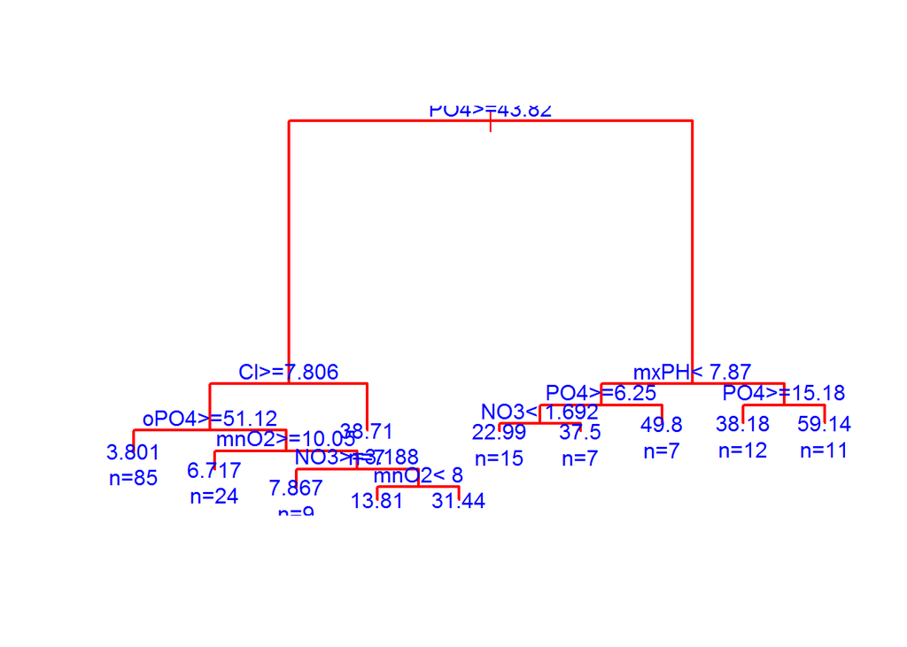

```r
par(lwd=2, col="red")
plot(rt.a1, compress=TRUE)
text(rt.a1, use.n=TRUE,col="blue")
```

### c. Pour évaluer la qualité de prévision:

```r
lm.predictions.a1 = predict(final.lm, algae)
rt.predictions.a1 = predict(rt.a1, algae)
regr.eval(algae[, "a1"], rt.predictions.a1, train.y = algae[,"a1"])
```

```
##         mae         mse        rmse        mape        nmse        nmae
##   8.3864223 155.7748824  12.4809808         Inf   0.3435142   0.5048102
```

```r
regr.eval(algae[, "a1"], lm.predictions.a1, train.y = algae[,"a1"])
```

```
##         mae         mse        rmse        mape        nmse        nmae
##  12.8240161 292.0602210  17.0897695         Inf   0.6440501   0.7719256
```

### d. Pour afficher les erreurs, on peut tracer la courbe des valeurs prédites contre les valeurs observées:

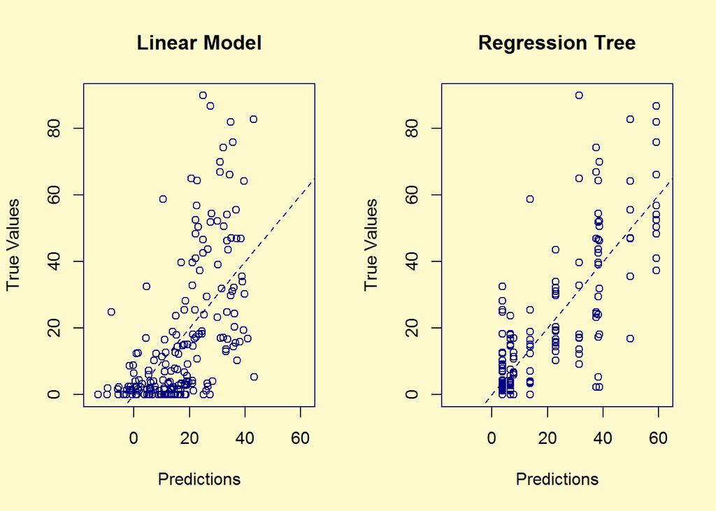

```r
par(mfrow = c(1, 2), col="navy", bg="lemonchiffon1")
plot(lm.predictions.a1, algae[, "a1"], main = "Linear Model",
xlab = "Predictions", ylab = "True Values", xlim=c(-15,62))
abline(0, 1, lty = 2)
plot(rt.predictions.a1, algae[, "a1"], main = "Regression Tree",
xlab = "Predictions", ylab = "True Values", xlim=c(-15,62))
abline(0, 1, lty = 2)
```